# P6_Chadeau_notebook5_quali_sex_categ

```python
from IPython.core.display import display, HTML
f = open("P6_Chadeau_notebook5_sommaire.html", "r", encoding="utf-8")
display(HTML(f.read()))
```

TOP  
Importation des librairies et fichiers  
Déclaration des fonctions  
Importation dataframe  
La mission

- Analyse des corrélations

- Corrélation entre le sexe des clients et les catégories de produits achetés

# Projet 6 -Analysez les ventes d'une librairie avec R ou Python

[figure not shown]

## NOTEBOOK 5 - ANALYSES BIVARIEES

### Importation des librairies et fichiers

```python
import pandas as pd
import numpy as np
import re
import matplotlib.pyplot as plt
import seaborn as sns
import datetime
from statsmodels.tsa.stattools import adfuller
from scipy.stats import chi2_contingency

#Permet d'afficher toutes les lignes d'une liste
pd.set_option("max_rows", None)

#Permet l'affichage de tous les résultats d'une cellule (pas seulement le dernier)
from IPython.core.interactiveshell import InteractiveShell
InteractiveShell.ast_node_interactivity = "all"

#Permet de définir des paramètres d'affichage pour l'ensemble des graphiques
from pylab import rcParams
rcParams['figure.figsize'] = 15, 5
```

### Déclaration des fonctions

### Importation dataframe

```python
#Import du fichier 'join_final', jointure des 3 dataframes customers, products et transactions

df=pd.read_csv("join_final.csv")
df['date']= pd.to_datetime(df['date'],errors = 'coerce')
df['birth']=df['birth'].astype('Int64')
df['Age']=df['Age'].astype('Int64')
df['mois']=df['date'].dt.month
#Le dataframe est indexé sur la colonne 'date' afin de pouvoir travailler sur la série temporelle
#en terme de période
df.set_index('date', inplace=True)

df_corrige=df.copy()
df_corrige=df_corrige.loc[(df_corrige['client_id']!='c_1609')&(df_corrige['client_id']!='c_6714')&\
                          (df_corrige['client_id']!='c_3454')&(df_corrige['client_id']!='c_4958')]
```

```python
#Import du fichier 'customers_clean'
df_customers_clean=pd.read_csv("customers_clean.csv")
df_customers_clean['Age']=2022-df_customers_clean['birth']
```

## Partie 3 - La mission (suite)

### Analyse des corrélations

### **Corrélation entre le sexe des clients et les catégories de produits achetés**

Il s'agit d'une corrélation entre 2 variables qualitatives.  
l'étude de la corrélation entre ces 2 types de variables sera faite via un test d'indépendance du χ2 (khi2). Ce test nous permet de définir quelle est la probabilité pour que la variable "catégorie" puisse être influencée par la variable "sexe"  
Le test est réalisé en plusieurs étapes :  
a) définition des hypothèses  
b) création du tableau de contingence  
c) détermination des effectifs théoriques et des conditions d'application du test  
d) détermination du nombre de degré de liberté  
e) détermination du χ2 critique et définition de la règle de décision

**a) Définition des hypothèses**

H0, l'hypothèse nulle : les variables 'sex' et 'categ' sont indépendantes  
H1, l'hypothèse alternative : les variables 'sex' et 'categ' sont dépendantes

**b) Création du tableau de contingences**

| categ sex | 0 | 1 | 2 | Total |
| --- | --- | --- | --- | --- |
| f | 200793 | 111331 | 16980 | 329104 |
| m | 186488 | 101017 | 15868 | 303373 |
| Total | 387281 | 212348 | 32848 | 632477 |

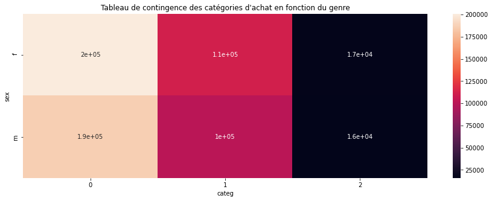

```python
#Création table de contingence avec les effectifs observées
X = "sex"
Y = "categ"
tab_obs = df_corrige[[X,Y]].pivot_table(index=X,columns=Y,aggfunc=len,margins=True,margins_name="Total")
tab_obs


memo=sns.heatmap(tab_obs.iloc[:-1,:-1],annot=tab_obs.iloc[:-1,:-1])
memo=plt.title("Tableau de contingence des catégories d'achat en fonction du genre")
plt.show()
```

On va également déterminer le pourcentage de chances de se tromper,le risque 𝛼, c’est-à-dire de rejeter à tort l'hypothèse nulle. On va choisir un seuil de probabilité de 5%, seuil le plus souvent choisi (=seuil de signification).

**c) Détermination des effectifs théoriques et des conditions d'application du test**  
Le tableau de contingence nous permet de déterminer les proportions d'homme et de femme dans l'échantillon pour chaque catégorie.  
Ces proportions vont permettre de calculer des valeurs théoriques s'il n'y avait aucune dépendance entre les variables.  
Calcul effectif théorique :  
Ti,j =((Total ligne i)/ Total général) * Total colonne j)

```python
#Création table de contingence avec les effectifs théoriques
tab_theoric=tab_obs.copy()
for i in [0,1,2]:
    for j in [0,1]:
        tab_theoric.iat[j,i]=round((tab_obs.iat[j,3]/tab_obs.iat[2,3])*tab_obs.iat[2,i])
tab_theoric
```

| categ sex | 0 | 1 | 2 | Total |
| --- | --- | --- | --- | --- |
| f | 201518 | 110493 | 17092 | 329104 |
| m | 185763 | 101855 | 15756 | 303373 |
| Total | 387281 | 212348 | 32848 | 632477 |

**d) Détermination du nombre de degré de libertés (DL)**  
D'une manière générale le nombre de degré de liberté est le nombre d'observations moins le nombre de paramètres à estimer entre ces observations. Il va nous permettre de déterminer la valeur critique  
ν=(nombre de lignes -1) x (nombre de colonnes -1)=(2-1) x (3-1) = 2

**e) Détermination du χ2 critique et définition de la règle de décision**  
On détermine la zone de rejet à partir de la table du Khi2 : Ici pour un nombre de liberte de 2 et pour un risque alpha de 5%, la valeur critique est de 5,99.

[figure not shown]

**f) Calcul du khi2**

[figure not shown]

```
Khi2 = 20.22
```

| categ sex | 0 | 1 | 2 |
| --- | --- | --- | --- |
| f | 2.608328 | 6.355552 | 0.733911 |
| m | 2.829546 | 6.894546 | 0.796141 |

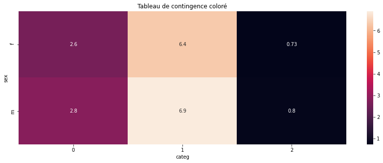

```python
khi2=0
tab_khi=tab_theoric.copy()
tab_khi=(tab_obs-tab_theoric)**2/tab_theoric
for i in [0,1]:
    for j in [0,1,2]:
        khi2=khi2+tab_khi[j][i]
print("Khi2 =",round(khi2,2))
tab_khi.iloc[:-1,:-1]
memo=sns.heatmap(tab_khi.iloc[:-1,:-1],annot=tab_khi.iloc[:-1,:-1])
memo=plt.title('Tableau de contingence coloré')
plt.show()
```

Comme χ2=20.22 > 5.99 = seuil critique alors avec un seuil de signification de 5% on peut affirmer qu'il existe un lien entre le sexe et la catégorie.  
On va le confirmer en trouvant la p-value, le degré de significativité (=le niveau de certitude).

```python
#Calcul du khi2 et de la p-value à partir de la matrice des valeurs observées avec scipy
#Degré de liberté = (nombre de lignes – 1) X (nombre de colonnes – 1)
chi2, pvalue, degrees,reste=chi2_contingency(tab_obs.iloc[:-1,:-1])
chi2, degrees, pvalue
```

```
(20.213460693513895, 2, 4.080400389217356e-05)
```

Comme :  
* khi2=20.22 > 5.99 = seuil critique  
et  
* p-value=4.08x10-5 < 0.01  
alors le test statistique est significatif : on peut rejeter l'hypothèse H0 : les variables "categ" et "sex" sont donc bien dépendantes l'une de l'autre.

[figure not shown]

Suite du projet : Analyses bivariées (suite)